# Dependency management

Lev Kovalenko

## Почему это важно?

- Repeatability
- Replicability
- Reusable

## История развития

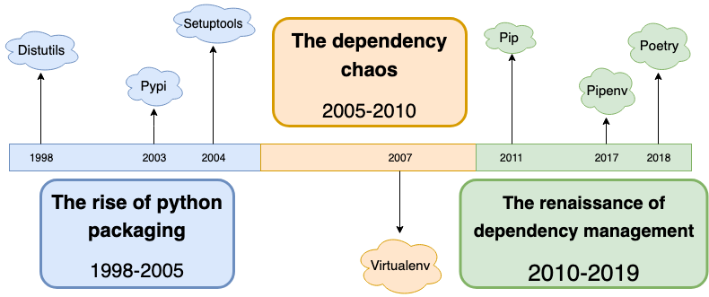

# Pip - default package manager

## Install packages

Установка пакетов.

```bash
pip install <package1> <package2>
```

Установка пакета определенной версии.

```bash
pip install <package1==version1> '<package2>=version2>'
```

Установка пакетов из `requirements.txt`.

```bash
pip install -r requirements.txt
```

Обновление уже установленного пакета.

```bash
pip install --upgrade <package>
```

Использование приватного индекса пакетов.

```bash
pip install --index-url <index-url> <package>
```

Установка пакетов из git.

```bash
pip install git+https://<git-package-url>@<version>
```

Установка пакетов с расширениями.

```bash
pip install <package>[<extras>]
```

Установка пререлизного пакета.

```bash
pip install --pre <package>
```

Установка своих пакетов в редактируемой режиме.

```bash
pip install --editable ./<package-path>
```

Установка своих пакетов из исходного кода.

```bash
pip install --no-binary <package>
```

## Dependecy resolver

- Появился `backtracking dependencies`
- Увеличена `строгость` резолвера
- Появился `state managment`
- Улучшилась поддержка `constraints`

## Requirement dependecies

Что бы зафиксировать требуемые зависимости можно:

```
pip freeze > requirements.txt
```

Строгая фиксация requirements.txt:

```
certifi==x.y.z
charset-normalizer==x.y.z
idna==x.y.z
requests==x.y.z
urllib3==x.y.z
```

Тонкая настройка requirements.txt:

```
certifi>=x.y.z
charset-normalizer>=x.y.z
idna>=x.y.z
requests>=x.y.z
urllib3>=x.y.z
```

## Dev/Prod dependecies

Зависимости для развертывания

```bash
# requirements.txt
package==1.0
package==1.0
package==1.0
```

Зависитмости для разработки

```bash
# dev_requirements.txt
-r requirements.txt
dev_package==1.0
dev_package==1.0
dev_package==1.0
```

## Pros&Cons

**Pros**

- default tool
- deterministic builds
- dependecy resolver

**Cons**

- no built-in isolation tool
- problematical dev and prod dependency split
- no tools for lib packaging and publishing
- buildings from source

# Conda - package, dependency and environment manager

## Conda packages

Структура пакета

```
.
├── bin
│   └── pyflakes
├── info
│   ├── LICENSE.txt
│   ├── files
│   ├── index.json
│   ├── paths.json
│   └── recipe
└── lib
    └── python3.5
```

Поиск пакетов:

```bash
conda search <package>
```

Установка пакетов:

```bash
conda install <package>
```

Сборка пакетов с помощью [conda-build](https://docs.conda.io/projects/conda-build/en/latest/index.html):

```bash
conda build <my_package>
```

## Conda channels

Установка из определенного `channel`

```bash
conda install scipy --channel conda-forge
```

Добавление `channel` по умолчанию

```bash
conda config --add channels new_channel
```

Список доступных `channels`:

```
anaconda
r
conda_forge
bioconda
astropy
metachannel
javascript
private
```

## Conda environments

Создание пустого окружения

```bash
conda create --name <myenv>
```

Создание питоноского окружения

```bash
conda create -n <myenv> python=3.9
```

Установка пакета в определенное окружение

```bash
conda install -n <myenv> <package>
```

Создание файла зависимостей

```bash
# только те которые были устанволены в ручную
conda env export --from-history > environment.yml
# все зависимости и сабзависимости
conda env export > environment.yml
```

Создание окружения из файла зависимостей

```bash
conda env create -f environment.yml
```

Обновление окружения из файла зависимостей

```bash
conda env update -f environment.yml
```

## Pros&Cons

**Pros**

- deterministic builds
- dependecy resolver
- built-in isolation tool
- tools for lib packaging and publishing
- builded binary packages

**Cons**

- very slow dependency resolver
- a lot of steps for preparing package build
- no dependencies split

# [Mamba](https://mamba.readthedocs.io/en/latest/)

# Poetry

## Project structure

Структура проекта

```
poetry-demo
├── pyproject.toml
├── poetry.lock
├── README.md
├── poetry_demo
│   └── __init__.py
└── tests
    └── __init__.py
```

Инициализация проекта

```bash
poetry new <project-path>
```

Pyproject.toml

```
[tool.poetry]
name = "poetry-demo"
version = "0.1.0"
description = ""
authors = ["Kovalenko Lev"]
readme = "README.md"
packages = [{include = "poetry_demo"}]

[tool.poetry.dependencies]
python = "^3.9"


[build-system]
requires = ["poetry-core"]
build-backend = "poetry.core.masonry.api"
```

## Dependency install

Установка пакета

```bash
poetry add <package>
```

Установка пакета определенной версии

```bash
# Allow >=2.0.5, <3.0.0 versions
poetry add package@^2.0.5
# Allow >=2.0.5, <2.1.0 versions
poetry add package@~2.0.5
# Allow >=2.0.5 versions, without upper bound
poetry add "package>=2.0.5"
# Allow only 2.0.5 version
poetry add package==2.0.5
```

Установка пакета из git

```bash
poetry add git+https://github.com/sdispater/package.git#version
```

Установка своих пакетов в редактируемой режиме

```bash
poetry add ---editable ./<package-path>
```

Добавление зависимости в определенную группу

```bash
poetry add <package> --group <group>
# для dev зависимостей
poetry add <package> --group dev
poetry add --dev <package>
```

Установка пререлизных зависимостей

```bash
poetry add --allow-prereleases <package>
```

Установка зависимостей из различных репозиториев

```bash
poetry source add <source> https://<source-link>
poetry add --source <source> <package>
```

Установка расширений зависимостей

```bash
poetry add "<package>[<extras>]"
```

```bash
poetry show --tree
```

Провести обновление зависимостей

```bash
# обновить конкретную зависимость
poetry add <package>@latest
poetry update <package>
# обновить под зависимости
poetry update
```

## Package build and publish

Сборка пакетов локально

```bash
poetry build
```

Публикация собранного пакета

```bash
poetry publish
```

Публикация и сборка пакета

```bash
poetry publish --build
```

Публикация пакета в приватный репозиторий

```bash
poetry publish -r <repo>
```

## Pros&Cons

**Pros**

- deterministic builds
- dependecy resolver
- dependecies groups
- built-in isolation tool
- tools for lib packaging and publishing
- dependencies update tracking

**Cons**

- buildings from source
- a very young tool

## Выводы

- pip - дефолтный менеджер пакетов, соответствует всем pep
- conda - лидер по environments, позволяет работать только с бинарными пакетами
- poetry - собрал в себя все лучшие практики, но очень молодая технология